# Homework Group 15

Basso - Genualdo - Privitera

July 12, 2019

# Exercise 1

## Part 1: visualization

```r
# data processing packages
suppressMessages(require(dplyr,  quietly = T))
suppressMessages(require(wrassp,  quietly = T))
suppressMessages(require(signal, quietly = T))
suppressMessages(require(tuneR, quietly = T))

# visualization packages
suppressMessages(require(dimRed, quietly = T))

# classification packages
suppressMessages(require(class, quietly = T))
suppressMessages(require(randomForest, quietly = T))
suppressMessages(require(kernlab, quietly = T))
```

The 150 songs are stored in .au format, by reading the [.au documentation](http://pubs.opengroup.org/external/auformat.html) we learned that they consist of long vectors of signed integers centered at $0$, which represent a discretization of the amplitude of sound measured at regular intervals. The freqency of said measurements is stored in the header of the file itself in the form of measurements per second (Hz).

[Apparently](https://en.wikipedia.org/wiki/Amplitude) amplitude is a measure of loudness at one point in time, so the first feature we tried to extract was some measure of average loudness in each song, which we found in the form of (Squared) Root Mean Square energy, or RMS energy, implemented in wrassp::rmsana.

```r
# sample size
n <- 150

# getting data
rms.result <- list()

for (j in 1:n) {
  rms.result[[j]] <- rmsana(paste("hw_data/hw_data/f", j, ".au", sep=""),
                            endTime = 25, windowSize = 1000, toFile=F)
}

# getting labels
labels <- read.table("hw_data/hw_data/Labels.txt")$x

str(rms.result[[1]])
```

```
## List of 1
##  $ rms: num [1:5011, 1] 75.1 75.1 75.2 75.2 75.3 ...
##  - attr(*, "trackFormats")= chr "REAL32"
##  - attr(*, "sampleRate")= num 200
##  - attr(*, "origFreq")= num 22050
##  - attr(*, "startTime")= num 0.00249
##  - attr(*, "startRecord")= int 1
##  - attr(*, "endRecord")= int 5011
##  - attr(*, "class")= chr "AsspDataObj"
##  - attr(*, "fileInfo")= int [1:2] 20 2
```

As seen above the RMS energy analysis is performed locally. As a first attempt we then computed the mean and standard deviation of these vectors to see if there were some significant differences.

```r
rms.avg <- rep(0,n)
rms.sd <- rep(0,n)

for (j in 1:n) {
  rms.avg[j] <- mean(rms.result[[j]]$rms)
  rms.sd[j] <- sd(rms.result[[j]]$rms)
}

level.mean <- list()
level.sd <- list()
for (level in levels(labels)) {
  level.indices <- which(labels == level)
  level.mean[[level]] <- mean(rms.avg[level.indices])
  level.sd[[level]] <- mean(rms.sd[level.indices])
}

# printing
do.call(rbind, Map(data.frame, Mean=level.mean, SD=level.sd))
```

```
##             Mean        SD
## country 73.37536 1.9879334
## hiphop  77.23286 1.9424830
## metal   73.82846 0.9715576
## reggae  73.44743 1.6751731
## rock    73.25700 1.5744509
```

No significant difference can be found in loudness, probabily because the recordings are normalized. This in turn suggests that these features can’t be used to reliably classify the data, except maybe for the standard deviation, which seems to hardly separate some genres. We thus turned to the analysis of the spectrum.

Our initial approach was to try to visualize and classify the data according to features such as the energy levels suggested in the homework text or MFCCs, which were backed up by some articles we read on the topic. None of these results proved particularly superior to the others though, generally achieving a 70 to 80% accuracy on the training set, and 40 to 50% on the test set. The use of dimensionality reduction tecniques such as PCA, LLE and IsoMaps only decreased training and test accuracy. Moreover none of these techniques proved useful to produce a 2d or 3d representation of the data that managed to separate any of the categories, not to mention that these results would not be intepretable anyway.

We will show here the MFCC results, comparing the performance of KNN, kernel SVM and Random Forest. Although it is now shown here we tried to select optimal tuning parameters with cross validation, but it showed little difference over performance.

```r
# mfcc parameters
ncep = 13
winsize = 2.
hoptime = winsize / 2

# getting data and applying mfcc
mfcc.result <- list()

# these will be of use later, ignore for now
mfcc.avg <- matrix(rep(0,n * ncep), nrow=n, ncol=ncep)
mfcc.sd <- matrix(rep(0,n * ncep), nrow=n, ncol=ncep)

for (j in 1:n) {
  song <- read.AsspDataObj(paste("hw_data/hw_data/f", j, ".au", sep=""))
  song.wv <- Wave( as.numeric(song$audio), samp.rate = rate.AsspDataObj(song), bit = 16)

  mfcc.result[[j]] <- melfcc(song.wv, wintime=winsize, hoptime=hoptime, numcep=ncep)

  # again, to be used later...
  mfcc.avg[j,] <- colMeans(mfcc.result[[j]])
  mfcc.sd[j,] <- sqrt(colMeans((mfcc.result[[j]]
                                - rep(1, dim(mfcc.result[[j]])[1]) %o% mfcc.avg[j,]) ^ 2))
}

# cutting data into a fixed length to form a matrix
dim1 <- function(mat) dim(mat)[1]
mfcc.lengths <- unlist(lapply(mfcc.result, dim1))
min.mfcc.length <- min(mfcc.lengths)

mfcc.mat <- matrix(rep(0, n * ncep * min.mfcc.length), nrow=n, ncol=ncep * min.mfcc.length)
for (j in 1:n) {
  mfcc.mat[j,] <- c(mfcc.result[[j]][1:min.mfcc.length,])
}

# freeing some memory
remove(mfcc.result)


# CLASSIFICATION
data.mat <- mfcc.mat

# creating training-testing partition
train.index <- sample(1:n, floor(0.8 * n), replace = F)
train.set <- data.mat[train.index,]
test.set <- data.mat[-train.index,]

# KNN classification
test.pred <- knn(train.set, test.set, labels[train.index], k=3)
conf.matrix <- caret::confusionMatrix(test.pred, labels[-train.index])
conf.matrix
```

```
## Confusion Matrix and Statistics
##
##           Reference
## Prediction country hiphop metal reggae rock
##    country       0      0     0      0    0
##    hiphop        0      8     0      0    1
##    metal         0      1     3      2    2
##    reggae        1      1     1      1    2
##    rock          2      1     1      0    3
##
## Overall Statistics
##
##                Accuracy : 0.5
##                  95% CI : (0.313, 0.687)
##     No Information Rate : 0.3667
##     P-Value [Acc > NIR] : 0.09395
##
##                   Kappa : 0.345
##
##  Mcnemar's Test P-Value : NA
##
## Statistics by Class:
##
##                      Class: country Class: hiphop Class: metal
## Sensitivity                     0.0        0.7273       0.6000
## Specificity                     1.0        0.9474       0.8000
## Pos Pred Value                  NaN        0.8889       0.3750
## Neg Pred Value                  0.9        0.8571       0.9091
## Prevalence                      0.1        0.3667       0.1667
## Detection Rate                  0.0        0.2667       0.1000
## Detection Prevalence            0.0        0.3000       0.2667
## Balanced Accuracy               0.5        0.8373       0.7000
##                      Class: reggae Class: rock
## Sensitivity                0.33333      0.3750
## Specificity                0.81481      0.8182
## Pos Pred Value             0.16667      0.4286
## Neg Pred Value             0.91667      0.7826
## Prevalence                 0.10000      0.2667
## Detection Rate             0.03333      0.1000
## Detection Prevalence       0.20000      0.2333
## Balanced Accuracy          0.57407      0.5966
```

```r
# SVM classification
svm <- ksvm(train.set, labels[train.index])
test.pred <- predict(svm, test.set)
conf.matrix <- caret::confusionMatrix(test.pred, labels[-train.index])
conf.matrix
```

```
## Confusion Matrix and Statistics
##
##           Reference
## Prediction country hiphop metal reggae rock
##    country       3      1     1      0    4
##    hiphop        0      3     0      0    0
##    metal         0      1     3      0    1
##    reggae        0      6     1      3    1
##    rock          0      0     0      0    2
##
## Overall Statistics
##
##                Accuracy : 0.4667
##                  95% CI : (0.2834, 0.6567)
##     No Information Rate : 0.3667
##     P-Value [Acc > NIR] : 0.1713
##
##                   Kappa : 0.3734
##
##  Mcnemar's Test P-Value : NA
##
## Statistics by Class:
##
##                      Class: country Class: hiphop Class: metal
## Sensitivity                  1.0000        0.2727       0.6000
## Specificity                  0.7778        1.0000       0.9200
## Pos Pred Value               0.3333        1.0000       0.6000
## Neg Pred Value               1.0000        0.7037       0.9200
## Prevalence                   0.1000        0.3667       0.1667
## Detection Rate               0.1000        0.1000       0.1000
## Detection Prevalence         0.3000        0.1000       0.1667
## Balanced Accuracy            0.8889        0.6364       0.7600
##                      Class: reggae Class: rock
## Sensitivity                 1.0000     0.25000
## Specificity                 0.7037     1.00000
## Pos Pred Value              0.2727     1.00000
## Neg Pred Value              1.0000     0.78571
## Prevalence                  0.1000     0.26667
## Detection Rate              0.1000     0.06667
## Detection Prevalence        0.3667     0.06667
## Balanced Accuracy           0.8519     0.62500
```

```r
# random forest classification
rf.classifier <- randomForest(x=train.set, y=labels[train.index],
                              xtest=test.set, ytest=labels[-train.index], keep.forest = T)
prediction <- predict(rf.classifier, test.set)
conf.table <- caret::confusionMatrix(prediction, labels[-train.index])
conf.table
```

```
## Confusion Matrix and Statistics
##
##           Reference
## Prediction country hiphop metal reggae rock
##    country       3      1     0      0    3
##    hiphop        0      6     0      0    0
##    metal         0      1     4      0    2
##    reggae        0      2     1      3    1
##    rock          0      1     0      0    2
##
## Overall Statistics
##
##                Accuracy : 0.6
##                  95% CI : (0.406, 0.7734)
##     No Information Rate : 0.3667
##     P-Value [Acc > NIR] : 0.007876
##
##                   Kappa : 0.5089
##
##  Mcnemar's Test P-Value : NA
##
## Statistics by Class:
##
##                      Class: country Class: hiphop Class: metal
## Sensitivity                  1.0000        0.5455       0.8000
## Specificity                  0.8519        1.0000       0.8800
## Pos Pred Value               0.4286        1.0000       0.5714
## Neg Pred Value               1.0000        0.7917       0.9565
## Prevalence                   0.1000        0.3667       0.1667
## Detection Rate               0.1000        0.2000       0.1333
## Detection Prevalence         0.2333        0.2000       0.2333
## Balanced Accuracy            0.9259        0.7727       0.8400
##                      Class: reggae Class: rock
## Sensitivity                 1.0000     0.25000
## Specificity                 0.8519     0.95455
## Pos Pred Value              0.4286     0.66667
## Neg Pred Value              1.0000     0.77778
## Prevalence                  0.1000     0.26667
## Detection Rate              0.1000     0.06667
## Detection Prevalence        0.2333     0.10000
## Balanced Accuracy           0.9259     0.60227
```

This pushed us to review our approach. Instead of building an (very) high dimensional representation of the data through some individual analysis of the song’s spectrograms, we tried to build simple estimates (such as average and standard deviation) from multiple spectrogram analysis techniques, namely:

- Mel-scaled frequency cepstral coefficients
- energy bands (using the code provided with the homework text)
- foundamental frequency contour
- zero crossing rate
- root mean squared energy, computed earlier in this markdown

We skipped autocorrelation, because it only seemed to decrease the accuracy of all teh classifiers.

For the spectrogram we used relatively wide windows, 2 seconds, since we learned about a phenomenon called the [Gabor limit](https://en.wikipedia.org/wiki/Uncertainty_principle#Signal_processing), which bounds the precision of the frequency measurement with the precision of the time measurement, similiarly to the famous Heisemberg uncertainty principle for position and momentum of a particle.

```r
# spectrogram parameters
song <- read.AsspDataObj("hw_data/hw_data/f1.au")
fs <- rate.AsspDataObj(song)

winsize = 2 * fs # 2 seconds
hopsize = winsize / 2
noverlap = winsize - hopsize

# energy bands parameters
nbands   <- 2^3
lowB <- 100
eps  <- .Machine$double.eps

# mfcc coefficients to keep
ncep = 13

# Number of seconds of the analyzed window
corrtime <- 15

# initializing
energy.avg <- matrix(rep(0, n * nbands), nrow = n, ncol = nbands)
energy.sd <- matrix(rep(0, n * nbands), nrow = n, ncol = nbands)

zcr.avg <- rep(0,n)
ffc.avg <- rep(0,n)

zcr.sd <- rep(0,n)
ffc.sd <- rep(0,n)

# filling features
for (j in 1:n) {
  song <- read.AsspDataObj(paste("hw_data/hw_data/f", j, ".au", sep=""))

  zcr.result <- zcrana(paste("hw_data/hw_data/f", j, ".au", sep=""),
                      endTime = 25, toFile=F)
  ffc.result <- ksvF0(paste("hw_data/hw_data/f", j, ".au", sep=""),
                      endTime = 25, toFile=F)

  # Sampling rate
  fs <- rate.AsspDataObj(song)
  # Short-time fourier transform
  sp  <- specgram(x = song$audio, n = winsize, Fs = fs, window = winsize, overlap = noverlap)
  ntm <- ncol(sp$S)  # number of (overlapping) time segments

  # Energy of bands
  fco    <- round( c(0, lowB*(fs/2/lowB)^((0:(nbands-1))/(nbands-1)))/fs*winsize)
  energy <- matrix(0, nbands, ntm)
  for (tm in 1:ntm){
    for (i in 1:nbands){
      lower_bound <- 1 + fco[i]
      upper_bound <- min( c( 1 + fco[i + 1], nrow(sp$S) ) )
      energy[i, tm] <- sum( abs(sp$S[ lower_bound:upper_bound, tm ])^2 )
    }
  }
  energy[energy < eps] <- eps
  energy = 10*log10(energy)

  # computing means and standard deviations
  energy.avg[j,] <- rowMeans(energy)
  energy.sd[j,] <- sqrt(rowMeans((energy - energy.avg[j,] %o% rep(1,ntm)) ^ 2))

  zcr.avg[j] <- mean(zcr.result$zcr)
  ffc.avg[j] <- mean(ffc.result$F0)

  zcr.sd[j] <- sd(zcr.result$zcr)
  ffc.sd[j] <- sd(ffc.result$F0)
}

# building data.frame
data <- data.frame(
  mfcc.avg = mfcc.avg, mfcc.sd = mfcc.sd,
  energy.avg = energy.avg, energy.sd = energy.sd,
  zcr.avg = zcr.avg, zcr.sd = zcr.sd,
  ffc.avg = ffc.avg, ffc.sd = ffc.sd,
  rms.avg = rms.avg, rms.sd = rms.sd,
  label = labels
  )
```

We then dispensed this cocktail of covariates to a random forest, to get the importance of each one in determining one song’s genre.

```r
rf.classifier <- randomForest(label ~., data, keep.forest = T)
conf.table <- caret::confusionMatrix(rf.classifier$predicted, labels)
conf.table
```

```
## Confusion Matrix and Statistics
##
##           Reference
## Prediction country hiphop metal reggae rock
##    country      23      0     0      4    6
##    hiphop        1     21     0      3    2
##    metal         0      1    27      0    6
##    reggae        3      5     1     20    3
##    rock          3      3     2      3   13
##
## Overall Statistics
##
##                Accuracy : 0.6933
##                  95% CI : (0.6129, 0.7659)
##     No Information Rate : 0.2
##     P-Value [Acc > NIR] : < 2.2e-16
##
##                   Kappa : 0.6167
##
##  Mcnemar's Test P-Value : NA
##
## Statistics by Class:
##
##                      Class: country Class: hiphop Class: metal
## Sensitivity                  0.7667        0.7000       0.9000
## Specificity                  0.9167        0.9500       0.9417
## Pos Pred Value               0.6970        0.7778       0.7941
## Neg Pred Value               0.9402        0.9268       0.9741
## Prevalence                   0.2000        0.2000       0.2000
## Detection Rate               0.1533        0.1400       0.1800
## Detection Prevalence         0.2200        0.1800       0.2267
## Balanced Accuracy            0.8417        0.8250       0.9208
##                      Class: reggae Class: rock
## Sensitivity                 0.6667     0.43333
## Specificity                 0.9000     0.90833
## Pos Pred Value              0.6250     0.54167
## Neg Pred Value              0.9153     0.86508
## Prevalence                  0.2000     0.20000
## Detection Rate              0.1333     0.08667
## Detection Prevalence        0.2133     0.16000
## Balanced Accuracy           0.7833     0.67083
```

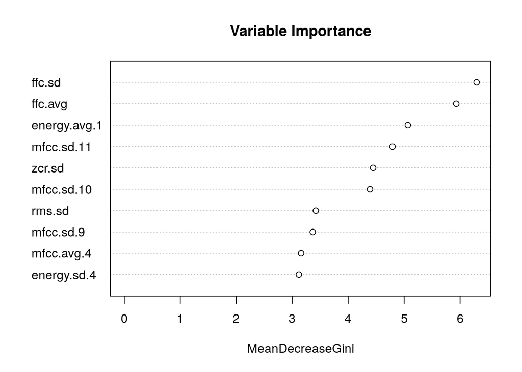

```r
varImpPlot(rf.classifier, n.var=10, main="Variable Importance")
```

```r
importance.df <- caret::varImp(rf.classifier)
best.vars <- row.names(importance.df)[order(-importance.df$Overall)][1:10]

trimmed.data <- select(data, best.vars)

cor(trimmed.data)
```

```
##                   ffc.sd     ffc.avg energy.avg.1  mfcc.sd.11      zcr.sd
## ffc.sd        1.00000000  0.77510133  -0.03341288  0.32637334  0.16998686
## ffc.avg       0.77510133  1.00000000  -0.08184312  0.49268162  0.02523812
## energy.avg.1 -0.03341288 -0.08184312   1.00000000 -0.19666151  0.31571862
## mfcc.sd.11    0.32637334  0.49268162  -0.19666151  1.00000000 -0.24686485
## zcr.sd        0.16998686  0.02523812   0.31571862 -0.24686485  1.00000000
## mfcc.sd.10    0.30512720  0.43424780  -0.16476845  0.67508153 -0.27624568
## rms.sd        0.30829687  0.39756329  -0.21808449  0.23381856  0.24448986
## mfcc.sd.9     0.35728549  0.51177608  -0.17957712  0.68554124 -0.16861562
## mfcc.avg.4   -0.24337576 -0.14072250  -0.10364244 -0.09868048 -0.35035004
## energy.sd.4   0.20941889  0.42454766  -0.24800544  0.55378832 -0.11361354
##              mfcc.sd.10     rms.sd  mfcc.sd.9  mfcc.avg.4 energy.sd.4
## ffc.sd        0.3051272  0.3082969  0.3572855 -0.24337576  0.20941889
## ffc.avg       0.4342478  0.3975633  0.5117761 -0.14072250  0.42454766
## energy.avg.1 -0.1647685 -0.2180845 -0.1795771 -0.10364244 -0.24800544
## mfcc.sd.11    0.6750815  0.2338186  0.6855412 -0.09868048  0.55378832
## zcr.sd       -0.2762457  0.2444899 -0.1686156 -0.35035004 -0.11361354
## mfcc.sd.10    1.0000000  0.2555432  0.6387070 -0.11460800  0.52886979
## rms.sd        0.2555432  1.0000000  0.3116250 -0.10350685  0.51685768
## mfcc.sd.9     0.6387070  0.3116250  1.0000000 -0.24121584  0.60587674
## mfcc.avg.4   -0.1146080 -0.1035068 -0.2412158  1.00000000 -0.08253395
## energy.sd.4   0.5288698  0.5168577  0.6058767 -0.08253395  1.00000000
```

We can see the the variables ffc.sd and ffc.avg are strongly correlated, but the two following these are not, namely energy.avg.1 and mfcc.sd.11. The following plot shows how mfcc.sd.11 and ffc.sd do indeed separate, but not cluster, three out of the five genres.

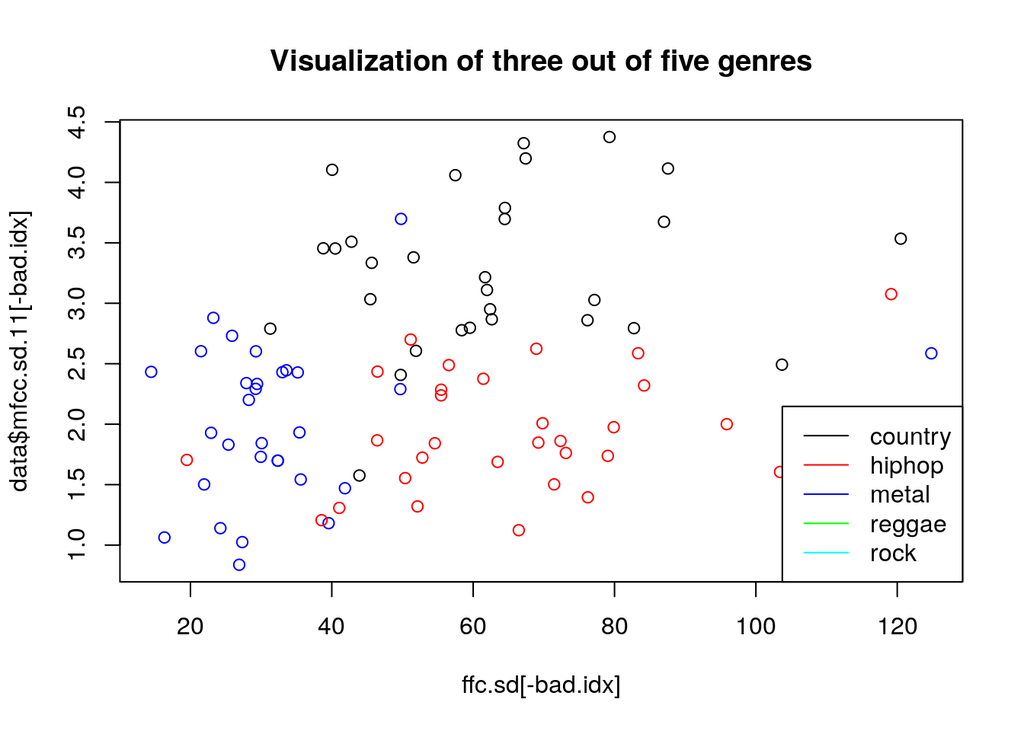

```r
# building color map
genre.names <- levels(labels)
color.list <- c("black", "red", "blue", "green", "cyan")
color.fun <- function(label) color.list[which(genre.names == label)]
color.map <- sapply(labels, color.fun)

# discarding rock and reggae
bad.idx = which((labels == "rock") | (labels == "reggae"))

plot(ffc.sd[-bad.idx], data$mfcc.sd.11[-bad.idx], col=color.map[-bad.idx],
     main="Visualization of three out of five genres")
legend("bottomright", legend=genre.names, col=color.list, lty=1,cex=1)
```

To try and imporove visualization, we resorted to 5 methods from the dimRed package that had been mentioned in class, namely PCA, Isomap, LLE and LaplacianEigenmaps.

```r
data.mat <- as.matrix(sapply(trimmed.data[,-ncol(data)], as.numeric), ncol=ncol(trimmed.data) - 1, nrow=n)

# coordinate transformation
embed_methods <- c("PCA", "Isomap", "LLE", "LaplacianEigenmaps", "DiffusionMaps")
data.emb <- lapply(embed_methods, function(x) embed(data.mat, x))
```

[output not shown]

[output not shown]

[output not shown]

[output not shown]

[output not shown]

[output not shown]

[output not shown]

```
## Eigenvalues: 5.483886e-01 6.818089e-02 5.583641e-18
```

[output not shown]

[output not shown]

Out of the 5 PCA, IsoMaps and LLE produced eye-pleasing results, and especially LLE managed to separate “rock” and “reggae” from eachother, but not from the other genres. We believe that this is due to the fact that not much else can be pulled from these covariates, which simply fail to describe the data well enough to be able to discern every genre.

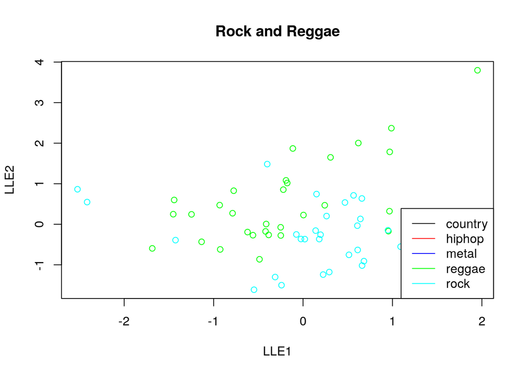

```r
plot(data.emb[[3]]@data@data[bad.idx,], col=color.map[bad.idx], main="Rock and Reggae")
legend("bottomright", legend=genre.names, col=color.list, lty=1,cex=1)
```

We felt like this was the best we could do for data visualization.

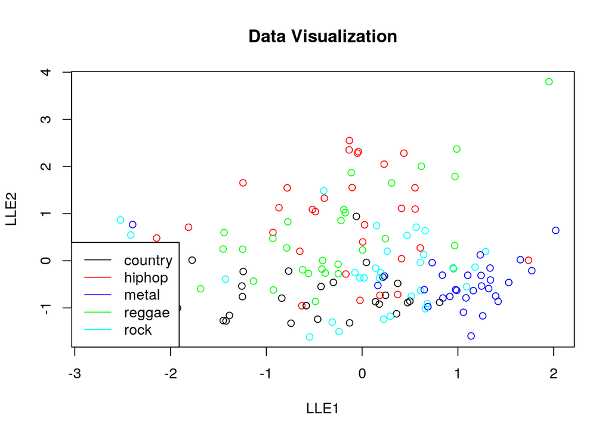

```r
plot(data.emb[[3]]@data@data, col=color.map, main="Data Visualization")
legend("bottomleft", legend=genre.names, col=color.list, lty=1,cex=1)
```

Why did we stop here? What’s reported here represents just a small part of the combinations of covariates we tried, and none of them solved the problem of visualization. Attempted improvements over this strategy mostly produced equivalent results. We believe that this is due to our ignorance in signal processing, and inability to make sensible use of the not so well documented wrassp functions.

## Part 2: classification

We tried 3 different classifiers

1. k-nearest neighbours
2. Gaussian kernel Support Vector Machines
3. Random Forests

We 5-cross-validated the first two to pick the best number of neighbours and the best kernel variance respectively.

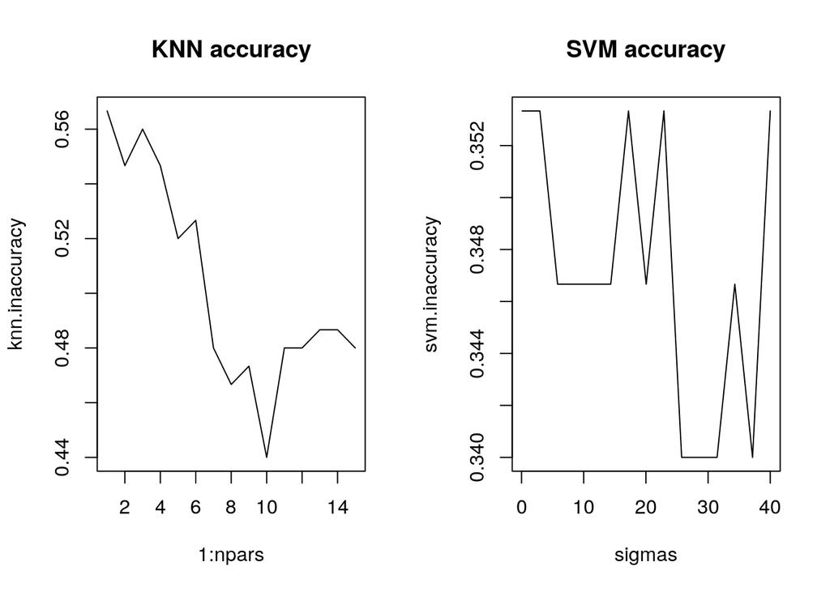

```r
data.mat <- as.matrix(sapply(data[,-ncol(data)], as.numeric), ncol=ncol(data) - 1, nrow=n)

npars <- 15
nfolds <- 5

sigmas <- seq(0.1, 40, length.out = npars)
fold.index <- caret::createFolds(labels, k=nfolds)

knn.inaccuracy <- rep(0,npars)
svm.inaccuracy <- rep(0,npars)

for (k in 1:npars) {
  for (ff in 1:nfolds) {
    # splitting data
    train.set <- data.mat[-fold.index[[ff]],]
    test.set <- data.mat[fold.index[[ff]],]

    train.labels <- labels[-fold.index[[ff]]]
    test.labels <- labels[fold.index[[ff]]]

    # KNN classifier
    knn.test <- knn(train.set, test=test.set, cl=train.labels, k=k)
    knn.inaccuracy[k] <- knn.inaccuracy[k] + 1 / nfolds * mean(test.labels != knn.test)

    # SVM classifier
    svm.class <- ksvm(train.set, train.labels, sigma=sigmas[k])
    svm.test <- predict(svm.class, test.set)
    svm.inaccuracy[k] <- svm.inaccuracy[k] + 1 / nfolds * mean(test.labels != svm.test)
  }
}

par(mfrow=c(1,2))
plot(1:npars, knn.inaccuracy, main="KNN accuracy", type='l')
plot(sigmas, svm.inaccuracy, main="SVM accuracy", type='l')
```

```r
best.k <- which.min(knn.inaccuracy)
best.sigma <- which.min(svm.inaccuracy)
```

```r
# creating training-testing partition
train.index <- sample(1:n, floor(0.8 * n), replace = F)
train.set <- data.mat[train.index,]
test.set <- data.mat[-train.index,]

# KNN classification
test.pred <- knn(train.set, test.set, labels[train.index], k=best.k)
knn.accuracy <- mean(test.pred == labels[-train.index])
knn.accuracy
```

```
## [1] 0.6
```

```r
# SVM classification
svm.obj <- ksvm(train.set, labels[train.index], sigma=best.sigma)
test.pred <- predict(svm.obj, test.set)
conf.matrix <- caret::confusionMatrix(test.pred, labels[-train.index])
conf.matrix
```

```
## Confusion Matrix and Statistics
##
##           Reference
## Prediction country hiphop metal reggae rock
##    country       7      0     0      0    0
##    hiphop        0      6     0      0    0
##    metal         0      0     7      0    1
##    reggae        0      1     0      4    0
##    rock          0      0     0      1    3
##
## Overall Statistics
##
##                Accuracy : 0.9
##                  95% CI : (0.7347, 0.9789)
##     No Information Rate : 0.2333
##     P-Value [Acc > NIR] : 1.629e-14
##
##                   Kappa : 0.8736
##
##  Mcnemar's Test P-Value : NA
##
## Statistics by Class:
##
##                      Class: country Class: hiphop Class: metal
## Sensitivity                  1.0000        0.8571       1.0000
## Specificity                  1.0000        1.0000       0.9565
## Pos Pred Value               1.0000        1.0000       0.8750
## Neg Pred Value               1.0000        0.9583       1.0000
## Prevalence                   0.2333        0.2333       0.2333
## Detection Rate               0.2333        0.2000       0.2333
## Detection Prevalence         0.2333        0.2000       0.2667
## Balanced Accuracy            1.0000        0.9286       0.9783
##                      Class: reggae Class: rock
## Sensitivity                 0.8000      0.7500
## Specificity                 0.9600      0.9615
## Pos Pred Value              0.8000      0.7500
## Neg Pred Value              0.9600      0.9615
## Prevalence                  0.1667      0.1333
## Detection Rate              0.1333      0.1000
## Detection Prevalence        0.1667      0.1333
## Balanced Accuracy           0.8800      0.8558
```

```r
# random forest
rf.classifier <- randomForest(x=train.set, y=labels[train.index],
                              xtest=test.set, ytest=labels[-train.index], keep.forest = T)
prediction <- predict(rf.classifier, test.set)
conf.table <- caret::confusionMatrix(prediction, labels[-train.index])
conf.table
```

```
## Confusion Matrix and Statistics
##
##           Reference
## Prediction country hiphop metal reggae rock
##    country       7      0     0      0    0
##    hiphop        0      7     0      0    0
##    metal         0      0     7      0    1
##    reggae        0      0     0      4    0
##    rock          0      0     0      1    3
##
## Overall Statistics
##
##                Accuracy : 0.9333
##                  95% CI : (0.7793, 0.9918)
##     No Information Rate : 0.2333
##     P-Value [Acc > NIR] : 5.25e-16
##
##                   Kappa : 0.9155
##
##  Mcnemar's Test P-Value : NA
##
## Statistics by Class:
##
##                      Class: country Class: hiphop Class: metal
## Sensitivity                  1.0000        1.0000       1.0000
## Specificity                  1.0000        1.0000       0.9565
## Pos Pred Value               1.0000        1.0000       0.8750
## Neg Pred Value               1.0000        1.0000       1.0000
## Prevalence                   0.2333        0.2333       0.2333
## Detection Rate               0.2333        0.2333       0.2333
## Detection Prevalence         0.2333        0.2333       0.2667
## Balanced Accuracy            1.0000        1.0000       0.9783
##                      Class: reggae Class: rock
## Sensitivity                 0.8000      0.7500
## Specificity                 1.0000      0.9615
## Pos Pred Value              1.0000      0.7500
## Neg Pred Value              0.9615      0.9615
## Prevalence                  0.1667      0.1333
## Detection Rate              0.1333      0.1000
## Detection Prevalence        0.1333      0.1333
## Balanced Accuracy           0.9000      0.8558
```

# Exercise 2A

```r
suppressMessages(require(mgcv,  quietly = T))
suppressMessages(require(KernSmooth,  quietly = T))
```

## Part 0

For later reference we show the component functions obtained by fitting the mgcv::gam model to the “ore” data.

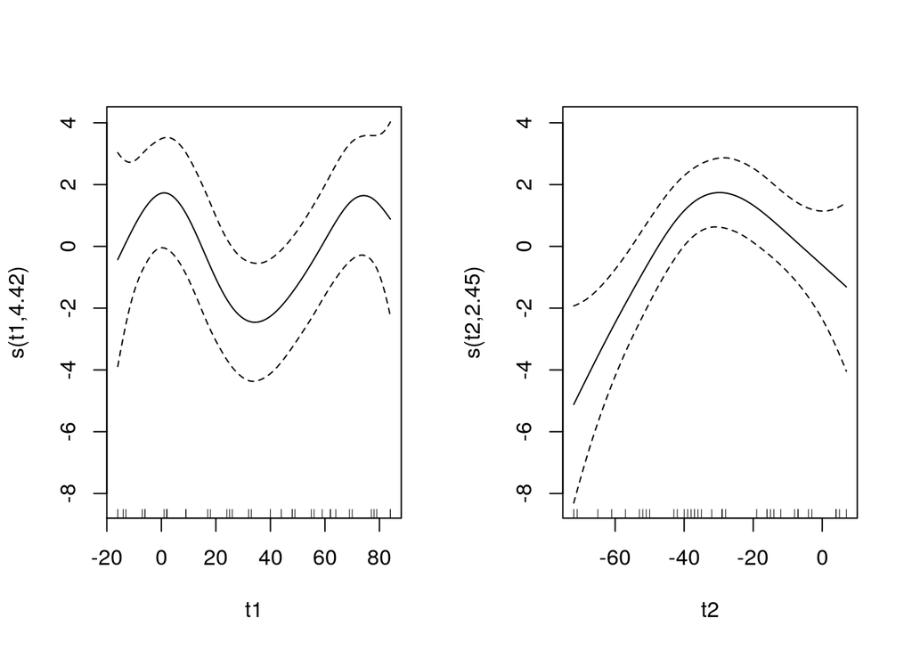

```r
load("hw_data/ore.RData")
ore.gam <- gam(width ~ s(t1) + s(t2), data = ore)
plot(ore.gam, pages = 1)
```

## Part 1

We first went for the riskier route proposed in Wasserman of selecting separate bandwidths for each covariate during every iteration of the backfitting algorithm. In the code that follows we define two functions.

The first performs a round of 4-fold Cross Validation to select the estimated smoother among the class of second degreee local polynomials. We came to this choice of smoother by following the recommendation on Wasserman, according to whom local polynomials of degree 1 should be the defalut choice of smoother. We then experimented with 0,1,2 and 3 degree local polynomials, observing that the second degree ones produced predictions closest to the ones from mgcv::gam. The choice of 4-fold cross validation was made to speed up the code, since it showed similar results to the classical 10-fold CV.

The second function implements the backfitting algorithm, calling the first one to perform smoothing.

```r
# 4-fold CV for 1d-local polynomial
cv.locpoly <- function(x,y, k=4) {
  CV.indices <- caret::createFolds(y, k=k)

  # cross-validating on 20 log-spaced bandwidths
  range.x <- range(x)
  meas.x <- range.x[2] - range.x[1]

  bw <- exp(seq(log(meas.x / length(x)), log(meas.x / 3), length.out=20))
  test.error <- rep(0, length(bw))

  for (i in 1:k) {
    # splitting data
    training.X <- x[-CV.indices[[i]]]
    training.Y <- y[-CV.indices[[i]]]

    validation.X <- x[CV.indices[[i]]]
    validation.Y <- y[CV.indices[[i]]]

    # estimating risk vs bandwidth
    for (b in 1:length(bw)) {
      y.hat <- locpoly(training.X, training.Y, degree=2, bandwidth=bw[b],
                      gridsize=200, range.x = range.x)
      y.hat.validation.X <- approx(y.hat$x, y.hat$y, xout=validation.X, rule=2)$y
      test.error[b] <- (test.error[b]
                        + 1/k * mean((y.hat.validation.X - validation.Y) ^ 2))
    }
  }

  # fitting using the optimal bandwidth
  bw.opt <- bw[which.min(test.error)]
  return(
    locpoly(x, y, degree=2, bandwidth=bw.opt, gridsize=200, range.x = range.x)
  )
}

# backfitting algorithm
backfit <- function (X,Y, incr_tol = 1e-02, maxiter = 1e+03) {
  d <- dim(X)[2]
  n <- dim(X)[1]

  row.range <- apply(X, 2, range)

  # initializing
  alpha.hat <- mean(Y)
  m <- list()
  M <- matrix(rep(0, d*n), nrow=n, ncol=d)
  r <- matrix(rep(0, d*n), nrow=n, ncol=d)

  # starting error
  rss0 <- sum((Y - alpha.hat - rowSums(M)) ^ 2)

  # running
  iter <- 0
  incr <- incr_tol + 1
  while ((incr > incr_tol) && (iter < maxiter)) {
    for (j in 1:d) {
      # updating residual
      r[,j] <- Y - alpha.hat - M[,-j]
      # smoothing residual
      sm.grid <- cv.locpoly(X[,j], r[,j])
      sm.fun <- approxfun(sm.grid$x, sm.grid$y, rule=2)
      M[,j] <- sm.fun(X[,j])
      # recentering
      M[,j] <- M[,j] - mean(M[,j])
      m[[j]] <- approxfun(X[,j], M[,j], rule=2)
    }

    # increment control
    rss <- sum((Y - alpha.hat - rowSums(M)) ^ 2)
    incr <- abs(rss - rss0) / rss
    rss0 <- rss
    iter <- iter + 1
  }

  # building additive model
  model <- function(x) {
    pred <- rep(alpha.hat, dim(x)[1])
    for (j in 1:dim(x)[2]) {
      pred <- pred + m[[j]](x[,j])
    }
    return(pred)
  }

  return(list(m=m, M=M, model=model, iterations=iter))
}
```

## Part 2

As instructed we then fitted the additive model on the “ore.Rdata” dataset. Here we plot the model’s prediction curves against the two original covariates t1,t2.

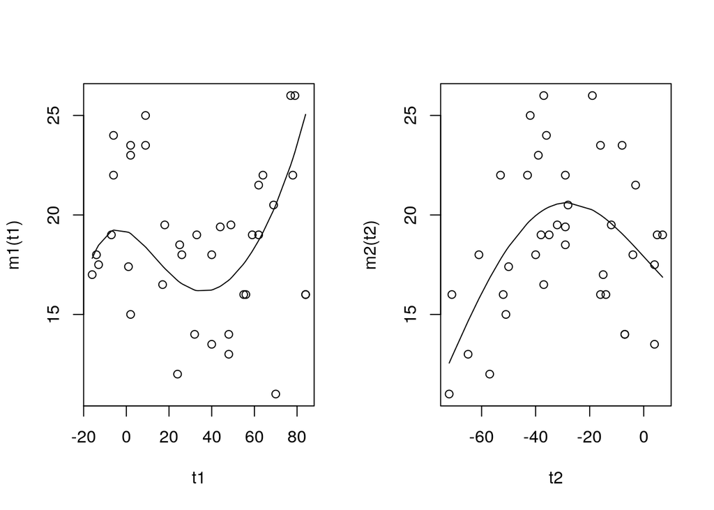

```r
# applying to ore data
X <- cbind(ore$t1, ore$t2)
add.model <- backfit(X, ore$width)

# plotting results
x1 <- seq(range(ore$t1)[1], range(ore$t1)[2], length.out=100)
x2 <- seq(range(ore$t2)[1], range(ore$t2)[2], length.out=100)

par(mfrow=c(1,2))

plot(ore$t1, ore$width, xlab='t1', ylab='m1(t1)')
lines(x1, mean(ore$width) + add.model$m[[1]](x1))

plot(ore$t2, ore$width, xlab='t2', ylab='m2(t2)')
lines(x2, mean(ore$width) + add.model$m[[2]](x2))

mtext("Component functions over datapoints", outer=T)
```

To compare our results to the ones obtained by mgcv::gam we computed the MSE on the datapoints and plotted the two overlaid functions $m_1, m_2$. The larger error in the first component function reflects the curve discrepancy observed in the first plot.

```r
# comparing to mgcv.gam predictions
gam.pred <- predict(ore.gam)

# ...through mse...
mse <- mean((gam.pred - add.model$model(X))^2)
print(mse)
```

```
## [1] 2.809361
```

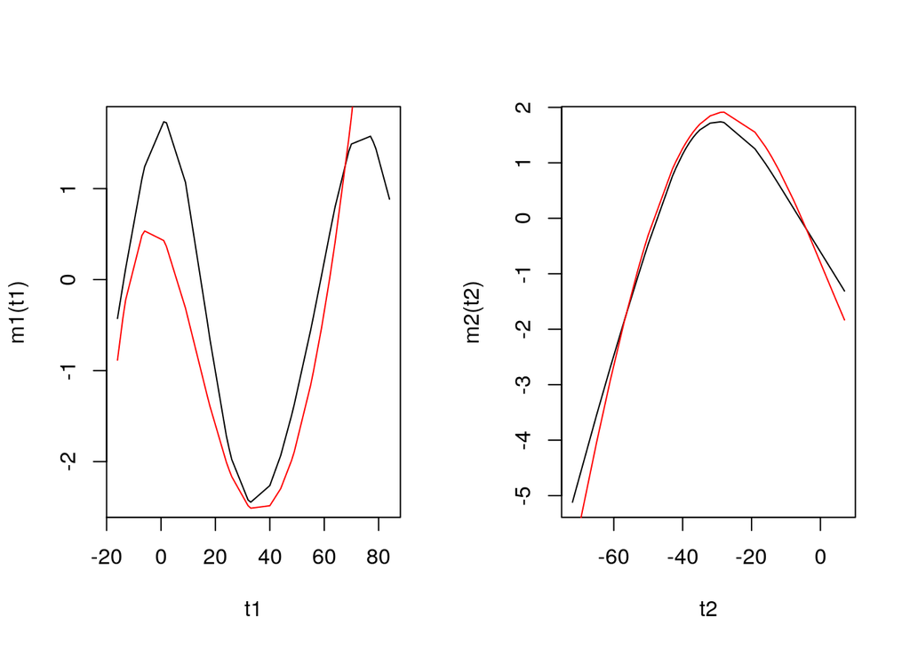

```r
# ...through overlaid plots
gam.terms <- predict(ore.gam, type='terms')
par(mfrow=c(1,2))

plot(ore$t1, gam.terms[,1], type='l', xlab='t1', ylab='m1(t1)')
lines(ore$t1, add.model$M[,1], col="red")

t2.sorted <- sort(ore$t2, index.return=T)
plot(t2.sorted$x, gam.terms[t2.sorted$ix,2], type='l', xlab='t2', ylab='m2(t2)')
lines(t2.sorted$x, add.model$M[t2.sorted$ix,2], col="red")

mtext("Component functions: mgcv::gam vs add.model", outer=T)
```

## Part 1, take 2

We were slightly unsatified with these results, mainly because the model failed to recognise the last downward trend in the width ~ t1 relationship, and we suspected that this was due to teh way we built the component functions $m_i$. We linearly interpolated the $M_{ij} = \widehat m_i(x_j)$ matrix returned by Kernsmooth::locpoly, which added a significant error of approximation. We thus implemented a simpler smoother, the Nadaraya–Watson kernel, in a function that returned both a callable object and a vector containing the function evaluated on the datapoints.

```r
k.smoother <- function(x,y,h) {
  n <- length(y)
  kernel <- function(v) dnorm(v / h)

  func <- function(v) {
    ret <- rep(0, length(v))
    for (j in 1:length(v)) {
      ret[j] <- y %*% kernel(v[j] - x) / sum(kernel(v[j] - x))
    }
    return(ret)
  }

  func.x <- func(x)
  diffs <- matrix(rep(x), nrow=n, ncol=n) - matrix(rep(x), nrow=n, ncol=n, byrow=T)

  # effective degrees of freedom = tr(L(X)), will be useful in exercise 2B
  df <- kernel(0) * sum(1 / rowSums(kernel(diffs)))

  return(list(func=func, y=func.x, df=df))
}
```

Here we chose to take the less adventurous route of normalizing the data and running a global round of 10-fold CV to estimate a global bandwidth for all the smoothers.

```r
backfit <- function (X,Y, smoother.bw, incr_tol = 1e-04, maxiter = 1e+03) {
  d <- dim(X)[2]
  n <- dim(X)[1]

  # initializing
  alpha.hat <- mean(Y)
  M <- matrix(rep(0, d*n), nrow=n, ncol=d)
  r <- matrix(rep(0, d*n), nrow=n, ncol=d)

  # starting error
  rss0 <- sum((Y - alpha.hat - rowSums(M)) ^ 2)

  # running
  sm.obj <- list()
  iter <- 0
  incr <- incr_tol + 1
  while ((incr > incr_tol) && (iter < maxiter)) {
    for (j in 1:d) {
      # updating residual
      r[,j] <- Y - alpha.hat - M[,-j]
      # smoothing residual
      sm.obj[[j]] <- k.smoother(X[,j], r[,j], h=smoother.bw)
      # recentering
      M[,j] <- sm.obj[[j]]$y - mean(sm.obj[[j]]$y)
    }

    # increment control
    rss <- sum((Y - alpha.hat - rowSums(M)) ^ 2)
    incr <- abs(rss - rss0) / rss
    rss0 <- rss
    iter <- iter + 1
  }

  # building additive model
  model <- function(x) {
    d <- dim(x)[2]
    n <- dim(x)[1]

    pred <- rep(alpha.hat, n)
    for (j in 1:d) {
      pred <- pred + sm.obj[[j]]$func(x[,j]) - mean(sm.obj[[j]]$y)
    }
    return(pred)
  }

  return(list(model=model, iterations=iter, M=M))
}
```

## Part 2, take 2

In the code that follows we apply the additive model to the normalized ore data.

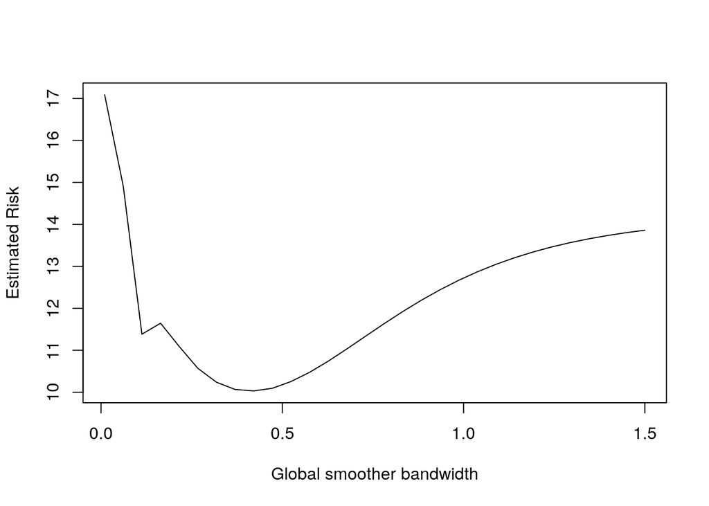

```r
# creating matrix of normalized covariates
trasf <- list()
trasf[[1]] <- function(v) (v - mean(ore$t1)) / sd(ore$t1)
trasf[[2]] <- function(v) (v - mean(ore$t2)) / sd(ore$t2)

trasf.t1 <- trasf[[1]](ore$t1)
trasf.t2 <- trasf[[2]](ore$t2)

X <- cbind(trasf.t1, trasf.t2)

# splitting for CV
k = 10
CV.indices <- caret::createFolds(ore$width, k=k)

# cross-validating on 30 bandwidths
bw <- seq(0.01, 1.5, length.out=30)
test.error <- rep(0, length(bw))

for (i in 1:k) {
  # splitting data
  training.X <- X[-CV.indices[[i]],]
  training.Y <- ore$width[-CV.indices[[i]]]

  validation.X <- X[CV.indices[[i]],]
  validation.Y <- ore$width[CV.indices[[i]]]

  # estimating risk vs bandwidth
  for (b in 1:length(bw)) {
    pred <- backfit(training.X, training.Y, smoother.bw = bw[b])
    test.error[b] <- test.error[b] + 1/k * mean((pred$model(validation.X) - validation.Y)^2)
  }
}

# fitting using the optimal bandwidth
par(mfrow=c(1,1))
plot(bw, test.error, type='l', xlab='Global smoother bandwidth', ylab='Estimated Risk')
```

```r
bw.opt <- bw[which.min(test.error)]
print(bw.opt)
```

```
## [1] 0.4210345
```

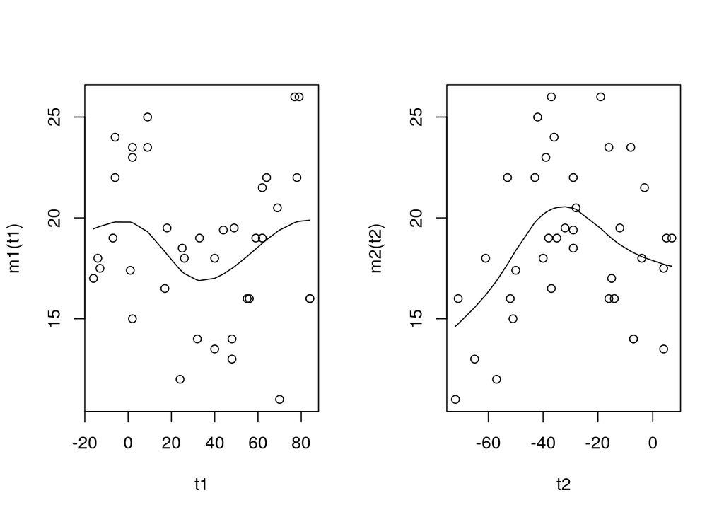

```r
pred <- backfit(X, ore$width, bw.opt)

# plotting component functions over data
par(mfrow=c(1,2))

plot(ore$t1, ore$width, xlab='t1', ylab='m1(t1)')
lines(ore$t1, mean(ore$width) + pred$M[,1])

plot(ore$t2, ore$width, xlab='t2', ylab='m2(t2)')
lines(t2.sorted$x, mean(ore$width) + pred$M[t2.sorted$ix,2])

mtext("Component functions over datapoints", outer=T)
```

```r
# comparing to mgcv.gam predictions
gam.pred <- predict(ore.gam)

# ...through mse...
mse <- mean((gam.pred - pred$model(X))^2)
print(mse)
```

```
## [1] 0.3393575
```

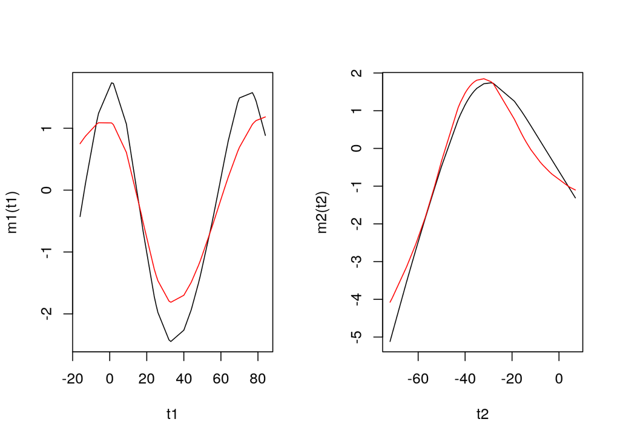

```r
# ...through overlaid plots
par(mfrow=c(1,2))

plot(ore$t1, gam.terms[,1], type='l', xlab='t1', ylab='m1(t1)')
lines(ore$t1, pred$M[,1], col="red")

t2.sorted <- sort(ore$t2, index.return=T)
plot(t2.sorted$x, gam.terms[t2.sorted$ix,2], type='l', xlab='t2', ylab='m2(t2)')
lines(t2.sorted$x, pred$M[t2.sorted$ix,2], col="red")

mtext("Component functions: mgcv::gam vs add.model", outer=T)
```

# Exercise 2B

After defining the training and testing data we present the MSE obtained using SAM::samQL. To obtain the best regularization parameter we tried performinga round of 10-fold CV on the samQL model as suggested in the homework text. In spite of this we ended up picking the smoothing parameter for the samQL estimator by hand. This is because the risk estimation given by the test error was identical for all the smoothing parameters. A code error on our side? Probably, but we weren’t able to spot it. We added the gaussian $\sim \mathcal{N}(0,1)$ noise on the training reponse vector y.tr, but not on the testing one.

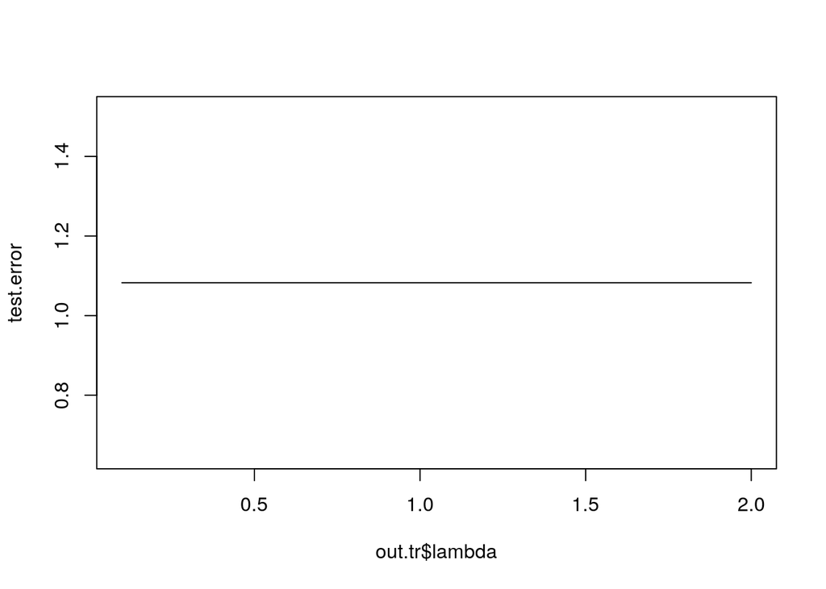

```r
suppressMessages(require(SAM,  quietly = T))

# Defining functions
m1 = function(x) -2 * sin(2 * x)
m2 = function(x) x^2 - 1/3
m3 = function(x) x - 0.5
m4 = function(x) exp(-x) + exp(-1) - 1

# Generating training data
n.tr = 150; d = 200
X.tr = 0.5*matrix(runif(n.tr*d),n.tr,d) + matrix(rep(0.5*runif(n.tr),d),n.tr,d)
# Generating response
y.tr = m1(X.tr[,1]) + m2(X.tr[,2]) + m3(X.tr[,3]) + m4(X.tr[,4]) + rnorm(n.tr)

# Generating testing data
n.te = 500; d = 200
X.te = 0.5*matrix(runif(n.te*d),n.te,d) + matrix(rep(0.5*runif(n.te),d),n.te,d)
# Generating response
y.te = m1(X.te[,1]) + m2(X.te[,2]) + m3(X.te[,3]) + m4(X.te[,4])


# splitting for CV
k = 10
CV.indices <- caret::createFolds(y.tr, k=k)

# cross-validating on 30 log-spaced bandwidths
lambdas <- seq(2, 0.1, length.out = 30)
nbandwidths <- length(lambdas)
test.error <- rep(0, nbandwidths)

for (i in 1:k) {
  # splitting data
  training.X <- X.tr[-CV.indices[[i]],]
  training.Y <- y.tr[-CV.indices[[i]]]

  validation.X <- X.tr[CV.indices[[i]],]
  validation.Y <- y.tr[CV.indices[[i]]]

  # Training: computes estimates for all lambdas at the same time according to documentation
  out.tr = samQL(training.X, training.Y, lambda=lambdas)
  # Testing
  out.te = predict(out.tr, validation.X)[[1]]

  # estimating risk vs bandwidth
  for (b in 1:nbandwidths) {
    test.error[b] <- test.error[b] + 1/k * mean((out.te[,b] - validation.Y)^2)
  }
}

# training on the best bandwidth
plot(out.tr$lambda, test.error, type='l')
```

```r
bw.opt <- out.tr$lambda[which.min(test.error)]
print(c('Optimal lambda', bw.opt))
```

```
## [1] "Optimal lambda" "2"
```

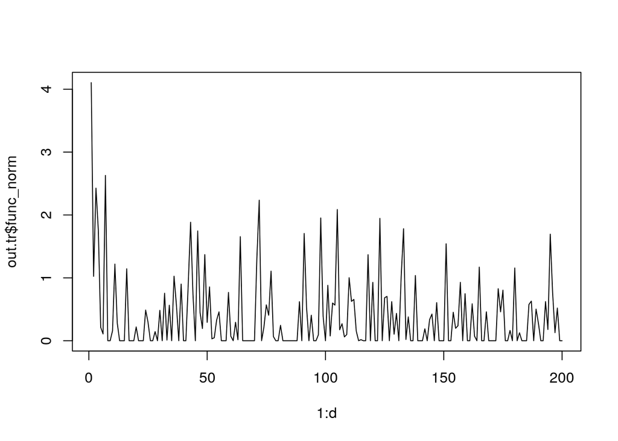

```r
out.tr <- samQL(X.tr, y.tr, lambda=0.001) # hand-picked bandwidth

# testing
out.te <- predict(out.tr, X.te)[[1]]

# plotting component function L2 norms
plot(1:d, out.tr$func_norm, type = 'l')
```

```r
error <- mean((out.te - y.te)^2)
print(c('MSE on X.te', error))
```

```
## [1] "MSE on X.te"       "0.609553699050482"
```

To furter assess the quality of the model we plotted the first 4 estimated component functions on top of $m_1, m_2, m_3, m_4$.

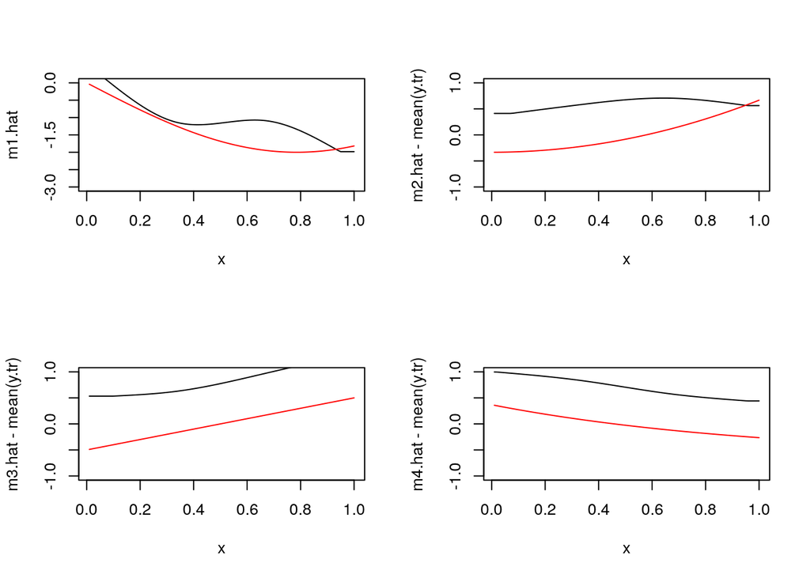

```r
build.test <- function(x,dd) {
  # returns a length(x) by d matrix having x as the dd-th column and zeros everywhere else

  ll <- length(x)
  z.mat <- matrix(rep(0,ll * d), nrow=ll, ncol=d)
  z.mat[,dd] <- x
  return(z.mat)
}

# getting component functions
x <- 1:100/100
m1.hat <- predict(out.tr, build.test(x,1))[[1]]
m2.hat <- predict(out.tr, build.test(x,2))[[1]]
m3.hat <- predict(out.tr, build.test(x,3))[[1]]
m4.hat <- predict(out.tr, build.test(x,4))[[1]]

# plotting component functions against the true ones
par(mfrow=c(2,2))
plot(x, m1.hat, ylim=c(-3,0), type='l')
lines(x, m1(x), col="red")
plot(x, m2.hat - mean(y.tr), ylim=c(-1,1), type='l')
lines(x, m2(x), col="red")
plot(x, m3.hat - mean(y.tr), ylim=c(-1,1), type='l')
lines(x, m3(x), col="red")
plot(x, m4.hat - mean(y.tr), ylim=c(-1,1), type='l')
lines(x, m4(x), col="red")

mtext("Estimated component functions (black) over $m_i$ (red)", outer=T)
```

$$\widehat R(\lambda_j) = \frac 1n \sum_{i=1}^n \left( \frac{y_i - \widehat f_n(X_i)}{1 - L_{ii}} \right)^2$$
with $\lambda_j$ being the bandwidth of $f_n$ and $L_{ii} = L_i(X_i)$.

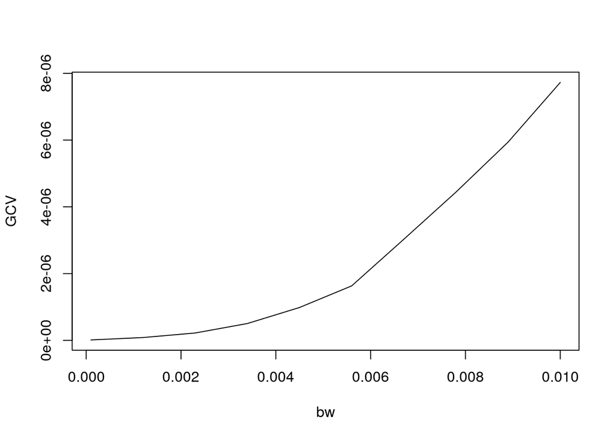

```r
k.smoother.loo <- function(j,x,y, bandwidths = exp(seq(log(5e-04), log(5e-02), length.out=5))) {
  risks <- rep(0, length(bandwidths))
  for (b in 1:length(bandwidths)) {
    risks[b] <- k.smoother(x,y, bandwidths[b])$risk
  }

  return(
    k.smoother(x,y, bandwidths[which.min(risks)])
  )
}

# sparse additive model implementation
spam <- function (X,Y, lambda, incr_tol = 1e-02, maxiter = 1e+02) {
  n <- dim(X)[1]
  d <- dim(X)[2]

  # initializing
  alpha.hat <- mean(Y)
  m <- list()
  sm.obj <- list()
  M <- matrix(rep(0, d*n), nrow=n, ncol=d)
  r <- matrix(rep(0, d*n), nrow=n, ncol=d)

  # starting error
  rss0 <- sum((Y - alpha.hat - rowSums(M)) ^ 2)

  # running
  iter <- 0
  incr <- incr_tol + 1
  while ((incr > incr_tol) && (iter < maxiter)) {
    for (j in 1:d) {
      # updating residual
      r[,j] <- Y - alpha.hat - rowSums(M[,-j])
      # smoothing residual
      #sm.obj[[j]] <- k.smoother.loo(j,X[,j], r[,j]) # performs CV on each linear smoother
      sm.obj[[j]] <- k.smoother(X[,j], r[,j], 0.02)  # hand-picked bandwidth
      u.hat <- sm.obj[[j]]$y
      l2.hat <- mean(u.hat ^ 2)
      M[,j] <- pmax(0, 1 - lambda / sqrt(l2.hat)) * u.hat
      # recentering
      M[,j] <- M[,j] - mean(M[,j])
    }

    # increment control
    rss <- sum((Y - alpha.hat - rowSums(M)) ^ 2)
    incr <- abs(rss - rss0) / rss
    rss0 <- rss
    iter <- iter + 1
  }

  # building additive model function
  model <- function(x) {
    pred <- rep(alpha.hat, dim(x)[1])
    for (j in 1:(dim(x)[2])) {
      pred <- pred + sm.obj[[j]]$func(x[,j]) - mean(M[,j])
    }
    return(pred)
  }

  # computing effective degrees of freedom
  edf <- rep(0,d)
  for (j in 1:d) {
    edf[j] <- sm.obj[[j]]$df
  }

  return(list(model=model, iterations=iter, M=M, edf=edf))
}


# compunting the optimal global penalization by minimizing the GCV estimate of the risk
bw <- seq(1e-04, 1e-02, length.out=10)
y.tr.bar <- mean(y.tr)

df <- rep(0, length(bw))
GCV <- rep(0, length(bw))

for (b in 1:length(bw)) {
  pred <- spam(X.tr, y.tr, lambda = bw[b])
  df[b] <- sum(pred$edf * (colSums((pred$M)^2) != 0))
  GCV[b] <- mean((y.tr - y.tr.bar - rowSums(pred$M)) ^ 2) / (1 - df[b] / n.tr) ^ 2
}


# fitting using the optimal bandwidth
par(mfrow=c(1,1))
plot(bw, GCV, type='l')
```

```r
bw.opt <- bw[which.min(GCV)]
print(c('Optimal lambda', bw.opt))
```

```
## [1] "Optimal lambda" "1e-04"
```

```r
spam.model <- spam(X.tr, y.tr, lambda=bw.opt)

error <- mean((spam.model$model(X.te) - y.te) ^ 2)
print(c('Test MSE', error))
```

```
## [1] "Test MSE"          "0.498686519060196"
```

The small bandwidths are due to the attempt of framing a minimum for the GCV estimates, which we were not able to obtain even for much smaller ones. As with the samQL estimate, we plot the estimated component functions over the true ones.

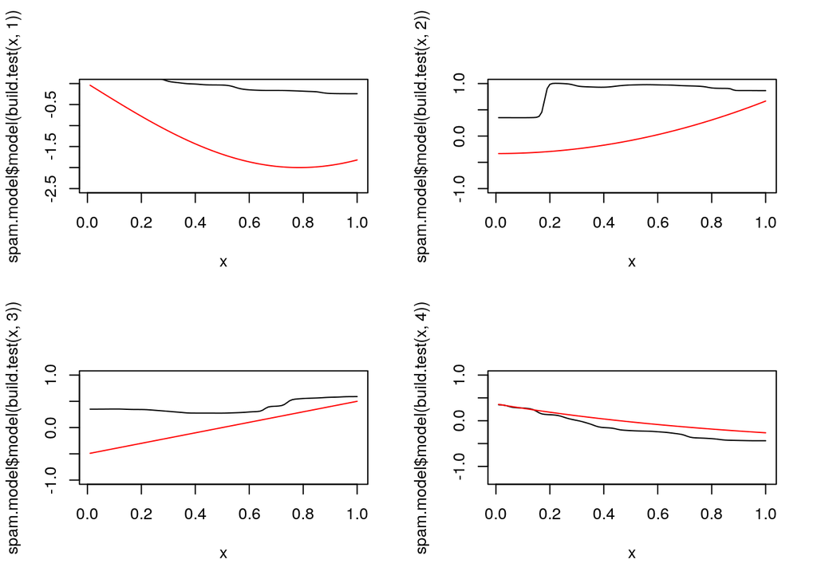

```r
# plotting component functions
par(mfrow=c(2,2))
plot(x, spam.model$model(build.test(x,1)), type='l', ylim=c(-2.5,0))
lines(x, m1(x), col="red")
plot(x, spam.model$model(build.test(x,2)), ylim=c(-1,1), type='l')
lines(x, m2(x), col="red")
plot(x, spam.model$model(build.test(x,3)), ylim=c(-1,1), type='l')
lines(x, m3(x), col="red")
plot(x, spam.model$model(build.test(x,4)), ylim=c(-1.3,1), type='l')
lines(x, m4(x), col="red")

mtext("Estimated component functions (black) over $m_i$ (red)", outer=T)
```